# Unsuppervized learning from domain rules

### Associative Memories and Energy Function

The mathematical framework for this endeavor revolves around associative memories. Consider M memories, each denoted as ρμ ∈ ℝᵈ, where μ ∈ [M]. The key elements here are the energy function and attractor dynamics, crucial for a clustering approach. A suitable energy function E(v) for clustering in a d-dimensional Euclidean space should be a continuous function of a point v ∈ ℝᵈ. It should possess M local minima, each corresponding to a memory, and as a particle approaches a memory, its energy should be primarily determined by that single memory. The energy function satisfying these requirements is given by: [E(v) = -\frac{1}{\beta} \log \sum_{\mu=1}^{M} \exp(-\beta| \rho_\mu - v |_2^2)] Here, β is a positive constant, interpreted as an inverse "temperature." As β increases, the energy function is dominated by the term corresponding to the closest memory, creating M basins of attraction around each memory.

### Integration with Jazzy

We initiate the fuzzy logic system using Jazzy, incorporating expert insights without explicit labels. The clustering loss, inspired by the energy function, refines domain rules without labels by optimising for data separation. Note that this approach requires a strong prior on domain rules to converge.

### Validation and Future Possibilities

To validate the effectiveness of this approach, only a minimal subset of examples needs explicit labels for traditional validation purposes. This example stands at the intersection of fuzzy logic, associative memories, and clustering without labels. It not only showcases the adaptability of Jazzy but also provides a glimpse into the potential of refining fuzzy logic systems in real-world scenarios with limited labeled data. **Future Possibilities:** This first implementation is pretty rough, a lot more work has to be done to find the right loss and hparams. The integration of clustering loss within Jazzy opens the door to exciting possibilities. Future experiments could explore:

- **Dynamic Clustering:** Adapting the clustering approach dynamically as the dataset evolves.
- **Transfer Learning:** Applying insights gained from one dataset to another, even in different domains.
- **Optimization Techniques:** Exploring various optimization methods for fine-tuning the fuzzy logic system.

```python
from itertools import chain
import sys
import os

from sklearn.metrics import classification_report
import numpy as np
import equinox as eqx
import jax
from tqdm import tqdm
import pandas as pd
import matplotlib.pyplot as plt

sys.path.append(os.path.dirname(__file__)+ '/../src')

from jazzy import (
    fuzzy_not,
    fuzzy_and,
    fuzzy_or,
    gt_fuzzifier,
    lt_fuzzifier,
    FuzzyParams,
    plot_fuzzy_gt,
    plot_fuzzy_lt,
)
```

```python
class FuzzyPenguinClassifier(eqx.Module):
    is_heavy_params: FuzzyParams
    has_long_flipper_params: FuzzyParams
    has_deep_culmen_params: FuzzyParams
    has_short_culmen_params: FuzzyParams

    def __init__(
        self,
        *,
        key,
    ) -> None:
        h_key, f_key, c_key, cl_key = jax.random.split(key, 4)
        self.is_heavy_params = FuzzyParams.initialize(key=h_key)
        self.has_long_flipper_params = FuzzyParams.initialize(key=f_key)
        self.has_deep_culmen_params = FuzzyParams.initialize(key=c_key)
        self.has_short_culmen_params = FuzzyParams.initialize(key=cl_key)

    def __call__(self, x):
        culmen_length, culmen_depth, flipper_length, body_mass = x

        is_heavy = gt_fuzzifier(body_mass, self.is_heavy_params)
        has_long_flipper = gt_fuzzifier(flipper_length, self.has_long_flipper_params)
        has_deep_culmen = gt_fuzzifier(culmen_depth, self.has_deep_culmen_params)
        has_short_culmen = lt_fuzzifier(culmen_length, self.has_short_culmen_params)

        is_gentoo = fuzzy_and(fuzzy_or(has_deep_culmen, is_heavy), has_long_flipper)
        is_adelie = fuzzy_and(fuzzy_not(is_gentoo), has_short_culmen)
        is_chinstrap = fuzzy_and(fuzzy_not(is_gentoo), fuzzy_not(is_adelie))

        indics = jax.numpy.stack((is_adelie, is_chinstrap, is_gentoo))
        return indics / indics.sum()
```

```python
def get_centroids(cluster_probs, data):
    hard_assignments = jax.numpy.argmax(cluster_probs, axis=1)

    # Create an index array for each cluster
    mask = (hard_assignments[:, None] == jax.numpy.arange(cluster_probs.shape[1]))

    # Use vectorized operations to compute cluster centroids without explicit loops
    centroids = (mask[:, :, None] * data[:, None, :]).sum(axis=0) / mask.sum(axis=0)[:, None]

    return centroids

def get_soft_centroids(cluster_probs, data):
    # Use vectorized operations to compute cluster centroids without explicit loops
    centroids = (cluster_probs[:, :, None] * data[:, None, :]).sum(axis=0) / cluster_probs.sum(axis=0)[:, None]

    return centroids

def energy_function(data, centroids, beta):
    """
    Compute the energy function E(v) for given data and centroids.
    From arXiv:2306.03209v1

    Parameters:
    - data: Input data array of shape (n, features)
    - centroids: Centroids array of shape (n_clusters, features)
    - beta: Positive constant

    Returns:
    - energy: Computed energy value
    """
    # Calculate squared Euclidean distances
    distances_squared = jax.numpy.sum((centroids[:, None] - data[None, :])**2, axis=-1)

    # Exponentiate and sum over centroids
    exp_term = jax.numpy.exp(-beta * distances_squared)
    sum_exp_term = exp_term.sum(axis=0)

    # Normalize and compute the negative logarithm
    energy = -jax.numpy.log(sum_exp_term).mean() / beta

    return energy
```

```python
def loss_fn(model, x, regu_weight=5, beta=5.0):
    y_hat = jax.vmap(model)(x)
    centroids = get_soft_centroids(y_hat, x)
    energy = energy_function(x, centroids, beta)

    sharpness = (
        model.is_heavy_params.sharpness
        + model.has_long_flipper_params.sharpness
        + model.has_deep_culmen_params.sharpness
        + model.has_short_culmen_params.sharpness
    )
    return energy + regu_weight / sharpness


grad_loss = jax.jit(jax.grad(loss_fn))
loss = jax.jit(loss_fn)


@jax.jit
def train_step(fuzzifier, x_test, learning_rate, regu_weight, beta):
    y_hat = jax.vmap(fuzzifier)(x_test)
    loss_step = loss(fuzzifier, x_test, regu_weight, beta)
    grads = grad_loss(fuzzifier, x_test)
    new_fuzzifier = jax.tree_map(lambda m, g: m - learning_rate * g, fuzzifier, grads)
    return y_hat, loss_step, grads, new_fuzzifier
```

```python
penguins_df = pd.read_csv("penguins_size.csv")

X = penguins_df[
    ["culmen_length_mm", "culmen_depth_mm", "flipper_length_mm", "body_mass_g"]
]
y = pd.get_dummies(penguins_df["species"])[["Adelie", "Chinstrap", "Gentoo"]]

is_train = ((pd.util.hash_array(penguins_df.index.values) % 100) / 100) > 0.2

X_train, X_test = X[is_train], X[~is_train]
y_train, y_test = y[is_train], y[~is_train]

X_train_mean = X_train.mean()

X_test = ((X_test - X_train.mean()) / X_train.std()).fillna(0)
X_train = ((X_train - X_train.mean()) / X_train.std()).fillna(0)
```

```python
clf = FuzzyPenguinClassifier(key=jax.random.PRNGKey(123))

print(clf(X_train.iloc[0]))
```

```
WARNING:absl:No GPU/TPU found, falling back to CPU. (Set TF_CPP_MIN_LOG_LEVEL=0 and rerun for more info.)
```

```
[0.49506804 0.28895313 0.21597885]
```

```python
preds = jax.vmap(clf)(X_test.values)

print(
    classification_report(
        np.argmax(y_test.values, axis=1),
        np.argmax(preds, axis=1),
        target_names=y_test.columns,
    )
)
```

```
              precision    recall  f1-score   support

      Adelie       0.63      1.00      0.77        34
   Chinstrap       1.00      0.07      0.12        15
      Gentoo       0.95      0.75      0.84        28

    accuracy                           0.73        77
   macro avg       0.86      0.61      0.58        77
weighted avg       0.82      0.73      0.67        77
```

```python
history = {"epoch": [], "loss": [], "grad_l1": [], "grad_linf": []}

learning_rate = 0.1
regu_weight = 1
beta=5.0

for epoch in tqdm(list(range(100000))):
    y_hat, loss_step, grads, clf = train_step(
        clf, X_train.values, learning_rate, regu_weight, beta
    )
    flat_grads = list(chain(*grads.tree_flatten()[0]))
    history["epoch"].append(epoch)
    history["loss"].append(loss_step)
    history["grad_l1"].append(sum(abs(g) for g in flat_grads) / len(flat_grads))
    history["grad_linf"].append(max(g for g in flat_grads))
```

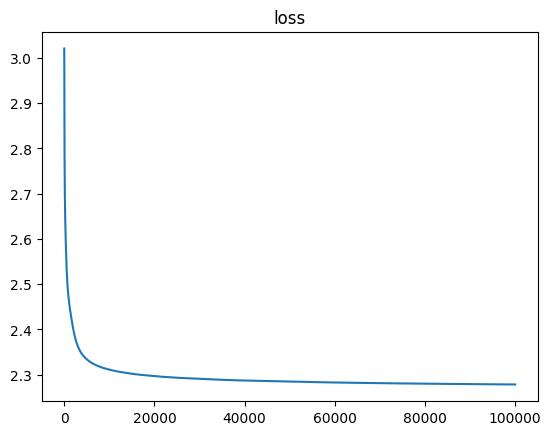

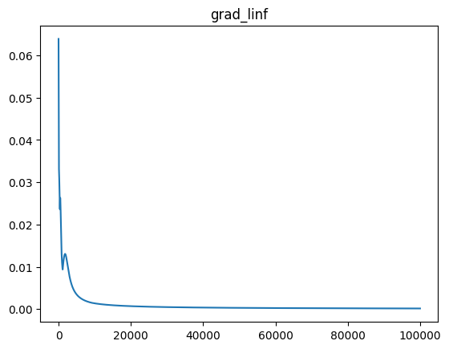

```python
plt.plot(history["epoch"], history["loss"])
plt.title("loss")
plt.figure()
plt.plot(history["epoch"], history["grad_linf"])
plt.title("grad_linf")
```

```python
preds = jax.vmap(clf)(X_test.values)

print(
    classification_report(
        np.argmax(y_test.values, axis=1),
        np.argmax(preds, axis=1),
        target_names=y_test.columns,
    )
)
```

```
              precision    recall  f1-score   support

      Adelie       0.71      1.00      0.83        34
   Chinstrap       1.00      0.07      0.12        15
      Gentoo       0.96      0.96      0.96        28

    accuracy                           0.81        77
   macro avg       0.89      0.68      0.64        77
weighted avg       0.86      0.81      0.74        77
```

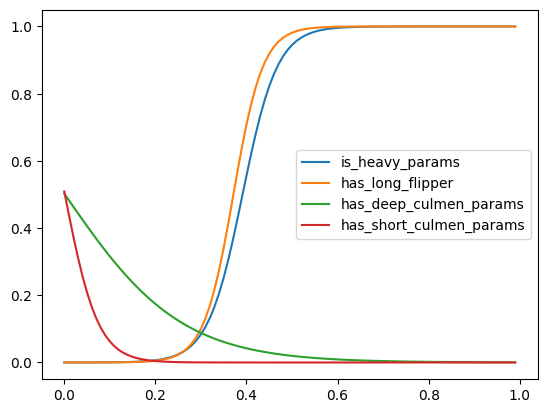

```python
plot_fuzzy_gt(
    [i / 100 for i in range(100)], clf.is_heavy_params, label="is_heavy_params"
)
plot_fuzzy_gt(
    [i / 100 for i in range(100)], clf.has_long_flipper_params, label="has_long_flipper"
)
plot_fuzzy_gt(
    [i / 100 for i in range(100)],
    clf.has_deep_culmen_params,
    label="has_deep_culmen_params",
)
plot_fuzzy_lt(
    [i / 100 for i in range(100)],
    clf.has_short_culmen_params,
    label="has_short_culmen_params",
)

plt.legend()
plt.figure()
```